# 钻石数据的探索性数据分析（R） by Batu Mengkai

### 3.3 价格和颜色之间的关系

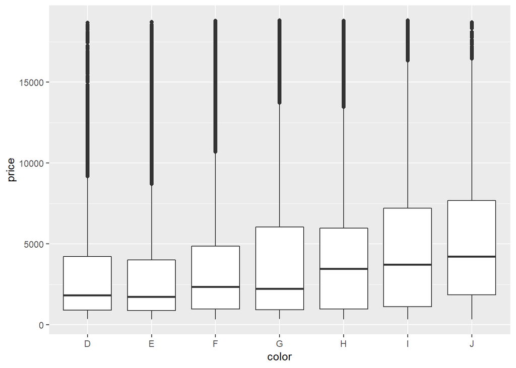

```r
ggplot(data = diamonds, aes(x = color, y = price))+
  geom_boxplot()
```

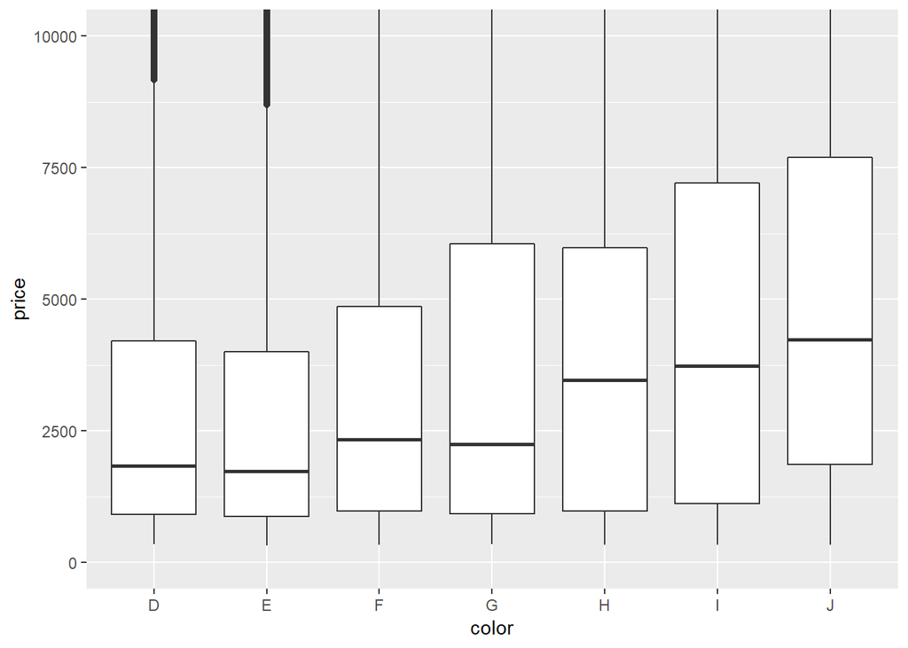

```r
ggplot(data = diamonds, aes(x = color, y = price))+
  geom_boxplot()+
  coord_cartesian(ylim = c(0,10000))
```

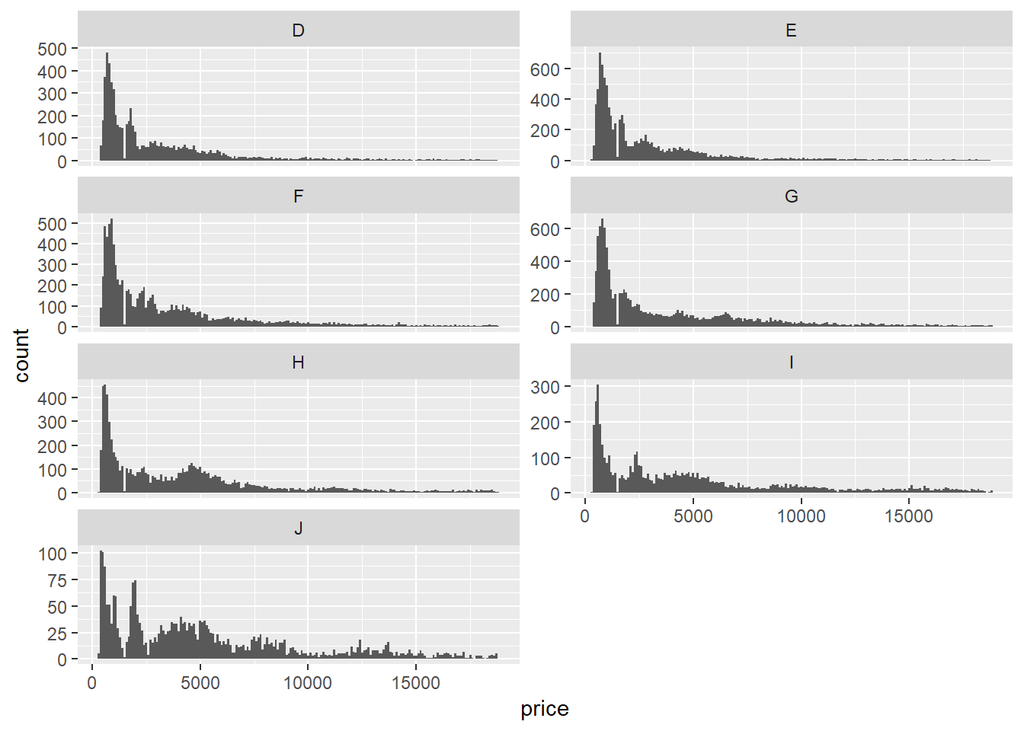

```r
ggplot(data = diamonds, aes(x= price))+
  geom_histogram(binwidth = 100)+
  facet_wrap(~color, ncol = 2, scales = "free_y")
```

**探索分析：**

- 从中位数对比看，随着颜色越好（D最好，J最差），价格反而在下降，这个很奇怪，可能价格高的钻石较大但是颜色质量差一些，还有就是J类型钻石数量比较少

### 3.4 价格和切割质量之间的关系

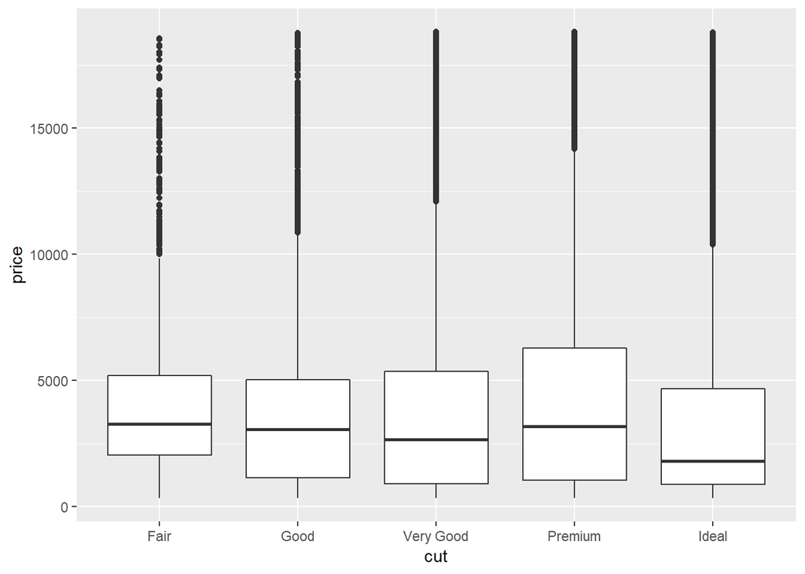

```r
ggplot(data = diamonds, aes(x = cut, y = price))+
  geom_boxplot()
```

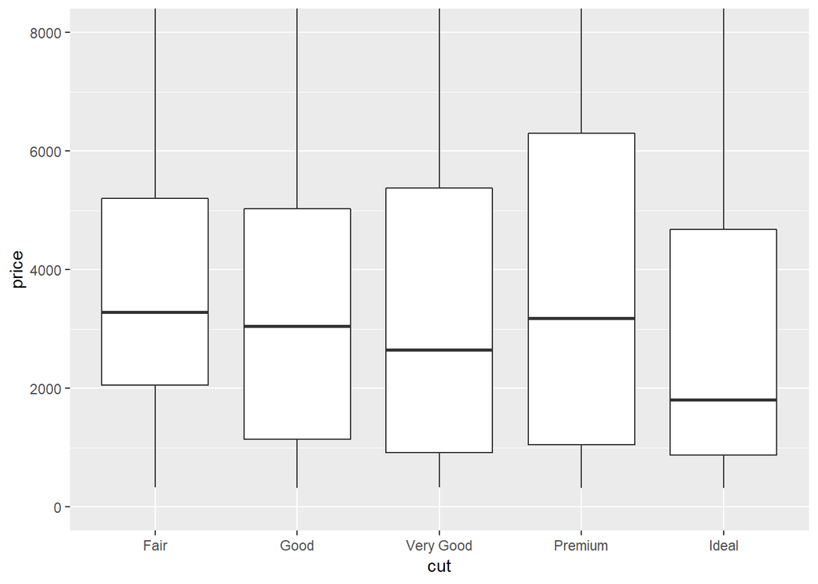

```r
ggplot(data = diamonds, aes(x = cut, y = price))+
  geom_boxplot()+
  coord_cartesian(ylim = c(0,8000))
```

```r
by(diamonds$price, diamonds$cut, summary)
```

```
## diamonds$cut: Fair
##    Min. 1st Qu.  Median    Mean 3rd Qu.    Max.
##     337    2050    3282    4359    5206   18574
## --------------------------------------------------------
## diamonds$cut: Good
##    Min. 1st Qu.  Median    Mean 3rd Qu.    Max.
##     327    1145    3050    3929    5028   18788
## --------------------------------------------------------
## diamonds$cut: Very Good
##    Min. 1st Qu.  Median    Mean 3rd Qu.    Max.
##     336     912    2648    3982    5373   18818
## --------------------------------------------------------
## diamonds$cut: Premium
##    Min. 1st Qu.  Median    Mean 3rd Qu.    Max.
##     326    1046    3185    4584    6296   18823
## --------------------------------------------------------
## diamonds$cut: Ideal
##    Min. 1st Qu.  Median    Mean 3rd Qu.    Max.
##     326     878    1810    3458    4678   18806
```

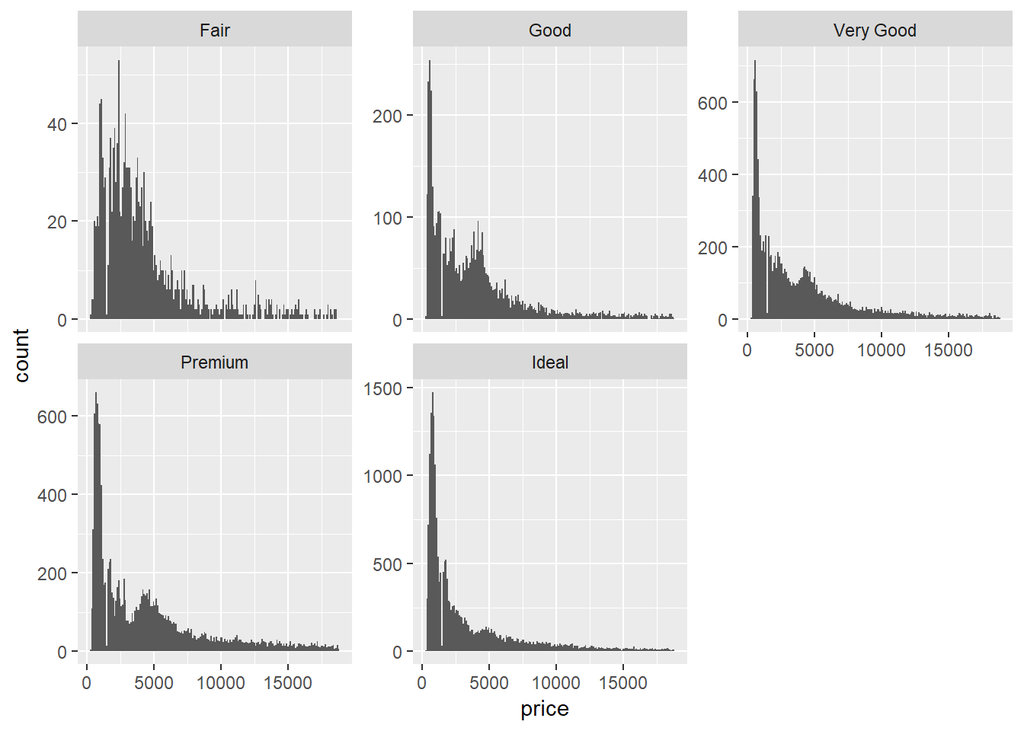

```r
ggplot(data = diamonds, aes(x = price))+
  geom_histogram(binwidth = 100)+
  facet_wrap(~cut, scales = "free_y")
```

**探索分析：**

- 对比中位数，切割质量为ideal的中位数最低,按常理是切割质量更好的钻石价格会更好
- 随着切割质量越好，价格中位数出现降低趋势，但不是绝对明显

### 3.5 价格和纯净度之间的关系

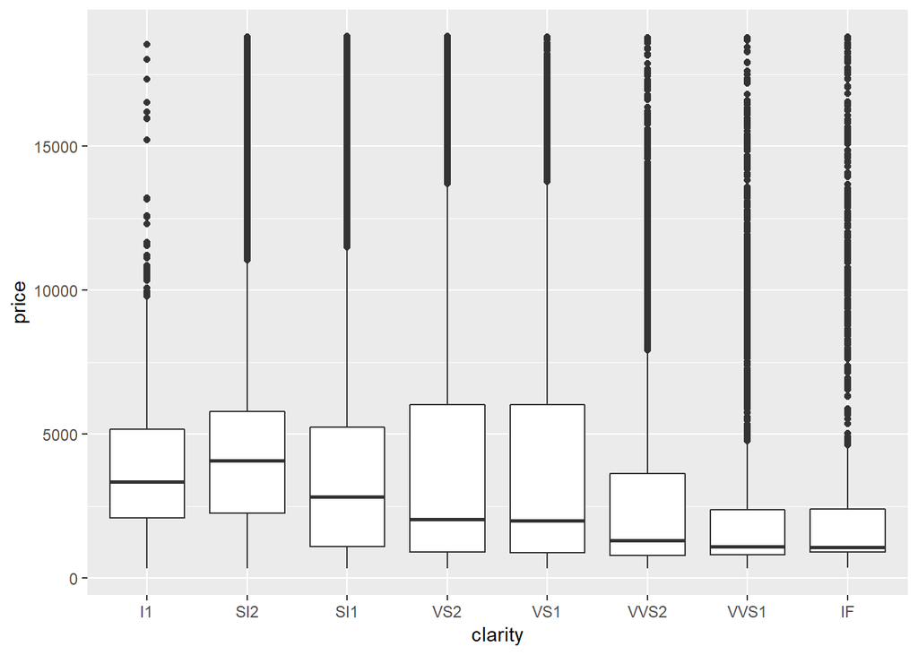

```r
ggplot(data = diamonds, aes(x = clarity, y = price ))+
  geom_boxplot()
```

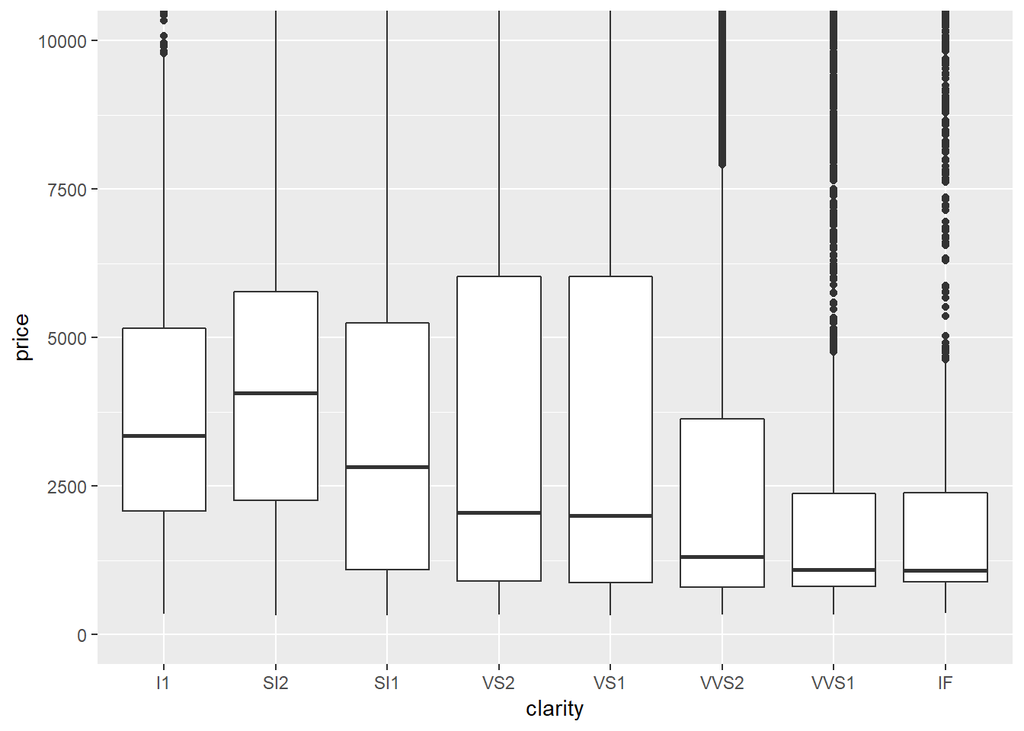

```r
ggplot(data = diamonds, aes(x = clarity, y = price ))+
  geom_boxplot()+
  coord_cartesian(ylim = c(0,10000))
```

```r
by(diamonds$price, diamonds$clarity, summary)
```

```
## diamonds$clarity: I1
##    Min. 1st Qu.  Median    Mean 3rd Qu.    Max.
##     345    2080    3344    3924    5161   18531
## --------------------------------------------------------
## diamonds$clarity: SI2
##    Min. 1st Qu.  Median    Mean 3rd Qu.    Max.
##     326    2264    4072    5063    5777   18804
## --------------------------------------------------------
## diamonds$clarity: SI1
##    Min. 1st Qu.  Median    Mean 3rd Qu.    Max.
##     326    1089    2822    3996    5250   18818
## --------------------------------------------------------
## diamonds$clarity: VS2
##    Min. 1st Qu.  Median    Mean 3rd Qu.    Max.
##     334     900    2054    3925    6024   18823
## --------------------------------------------------------
## diamonds$clarity: VS1
##    Min. 1st Qu.  Median    Mean 3rd Qu.    Max.
##     327     876    2005    3839    6023   18795
## --------------------------------------------------------
## diamonds$clarity: VVS2
##    Min. 1st Qu.  Median    Mean 3rd Qu.    Max.
##   336.0   794.2  1311.0  3283.7  3638.2 18768.0
## --------------------------------------------------------
## diamonds$clarity: VVS1
##    Min. 1st Qu.  Median    Mean 3rd Qu.    Max.
##     336     816    1093    2523    2379   18777
## --------------------------------------------------------
## diamonds$clarity: IF
##    Min. 1st Qu.  Median    Mean 3rd Qu.    Max.
##     369     895    1080    2865    2388   18806
```

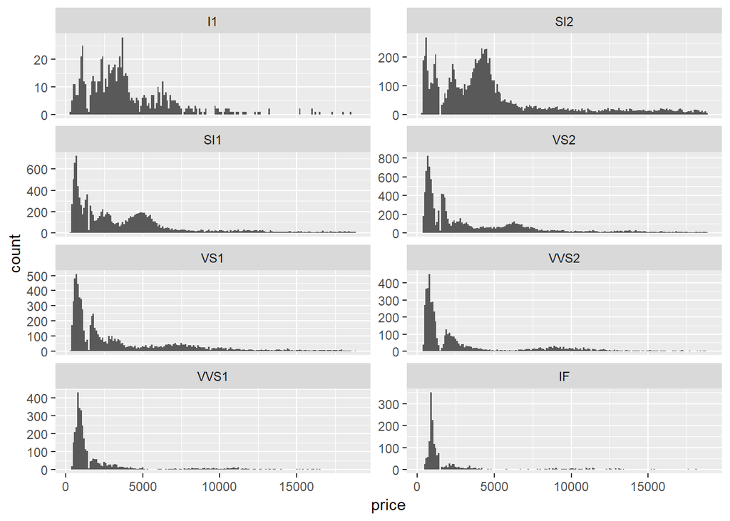

```r
ggplot(data = diamonds, aes(x = price))+
  geom_histogram(binwidth = 100)+
  facet_wrap(~clarity, scales = "free_y", ncol = 2)
```

**探索分析**

- I1 (最差)- IF (最好)
- 随着纯净度提高，钻石价格反而降低，纯净度最高的钻石价格中位数最低，这个不符合之前的直觉
- 随着钻石纯净度升高，钻石价格的离散程度逐渐变大再变小

### 3.6 价格与分别与深度比例depth和table值的关系

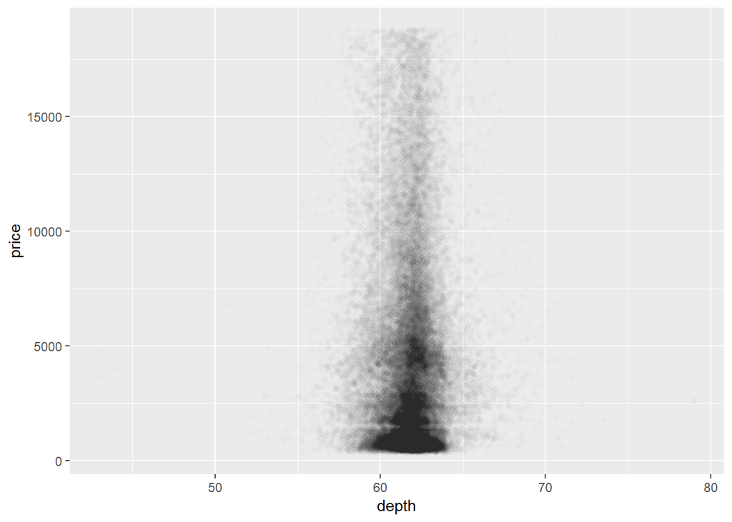

```r
ggplot(data = diamonds, aes(x = depth, y = price))+
  geom_point(alpha = 1/100, position = position_jitter())
```

```r
summary(diamonds$depth)
```

```
##    Min. 1st Qu.  Median    Mean 3rd Qu.    Max.
##   43.00   61.00   61.80   61.75   62.50   79.00
```

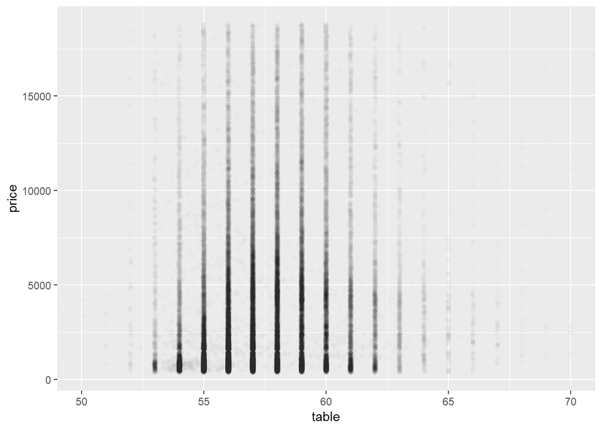

```r
ggplot(data = diamonds, aes(x = table, y = price))+
  geom_point(alpha = 1/100, position = position_jitter())+
  coord_cartesian(xlim = c(50,70))
```

**探索分析**

- 随着depth,table增加，价格没有明显变化趋势
- depth,table对影响价格变化不是很大

### 3.7 通过对两个变量之间关系分析得到以下总结：

1. 钻石价格与钻石克拉数及x,y,z尺寸有很强的相关性，符合常理，因为钻石越大价格越高
2. 钻石价格与depth,table没有出现明显相关性趋势
3. 随着纯净度提高，钻石价格反而降低，纯净度最高的钻石价格中位数最低，这个不符合之前的直觉
4. 对比不同切割质量的价格中位数，切割质量为ideal的价格中位数最低,按常理是切割质量更好的钻石价格会更好，随着切割质量越好，价格中位数出现降低趋势，但不是绝对明显
5. 对比不同颜色对应价格的中位数，随着颜色越好（D最好，J最差），价格反而在下降，这个很奇怪，可能价格高的钻石较大但是颜色质量差一些，还有就是J类型钻石数量比较少

## 4.探索多个变量之间的分析

### 4.1 对价格和克拉进行数据转化

- 价格受不同消费层级以及通货膨胀影响，所以进行log10转化压缩

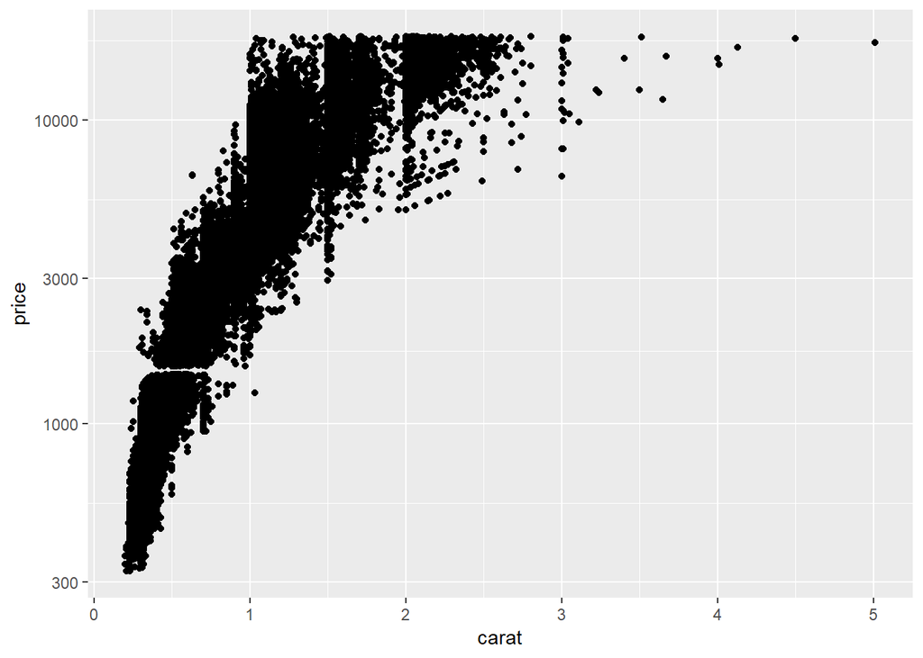

```r
ggplot(data = diamonds, aes(x = carat, y = price))+
  geom_point()+
  scale_y_log10()
```

- 可以相关性更靠近线性了
- 现在对克拉进行开立方的转化，因为体积单位是立方的，将其转化到立方上查看

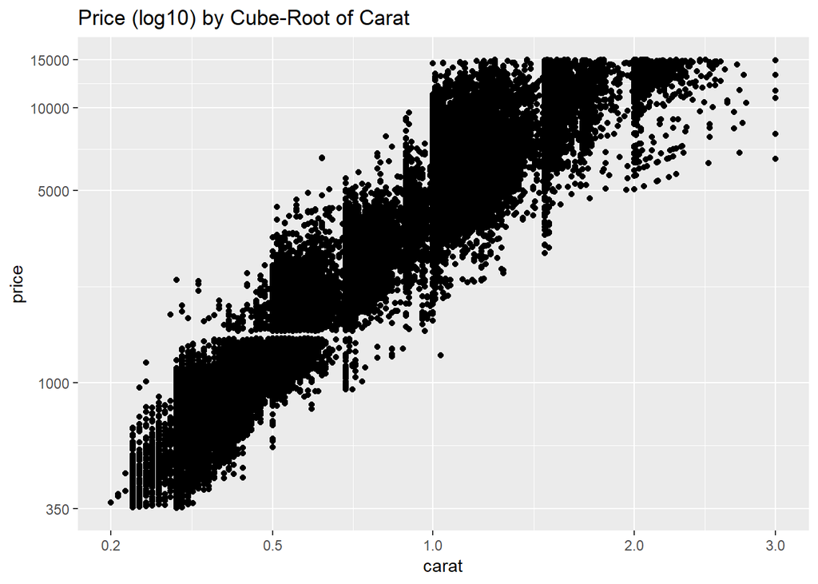

```r
cuberoot_trans = function() trans_new('cuberoot', transform = function(x) x^(1/3),
                                      inverse = function(x) x^3)
#这个函数是将数值开立方根的函数

ggplot(aes(carat, price), data = diamonds) +
  geom_point() +
  scale_x_continuous(trans = cuberoot_trans(), limits = c(0.2, 3),
                     breaks = c(0.2, 0.5, 1, 2, 3)) +
  scale_y_continuous(trans = log10_trans(), limits = c(350, 15000),
                     breaks = c(350, 1000, 5000, 10000, 15000)) +
  ggtitle('Price (log10) by Cube-Root of Carat')
```

```r
with(diamonds, cor.test(x = log10(price), y = carat^1/3), method = "pearson")
```

```
##
##  Pearson's product-moment correlation
##
## data:  log10(price) and carat^1/3
## t = 545.98, df = 53938, p-value < 2.2e-16
## alternative hypothesis: true correlation is not equal to 0
## 95 percent confidence interval:
##  0.9189034 0.9214897
## sample estimates:
##       cor
## 0.9202066
```

### 4.2 价格、克拉及颜色三者的关系

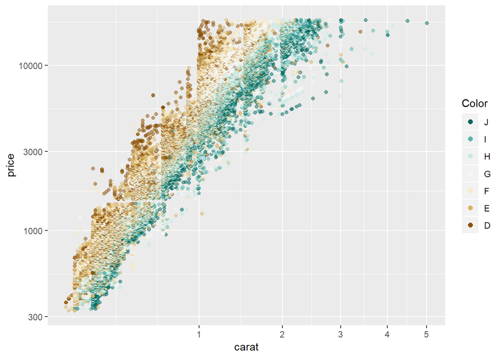

```r
ggplot(data = diamonds, aes(x = carat, y = price, color = color))+
  geom_point(alpha= 1/2,position = position_jitter())+
  scale_x_continuous(trans = cuberoot_trans())+
  scale_y_continuous(trans = log10_trans())+
  scale_color_brewer(type = 'div',
                     guide = guide_legend(title = 'Color', reverse = T,
                                          override.aes = list(alpha = 1, size = 2)))
```

**探索分析**

- 从上图可以看出，在同一颜色下，log10(price)和carat^1/3呈现线性关系
- 在同一克拉下，颜色越好，其价格就越高

### 4.3 价格、克拉及切割质量三者的关系

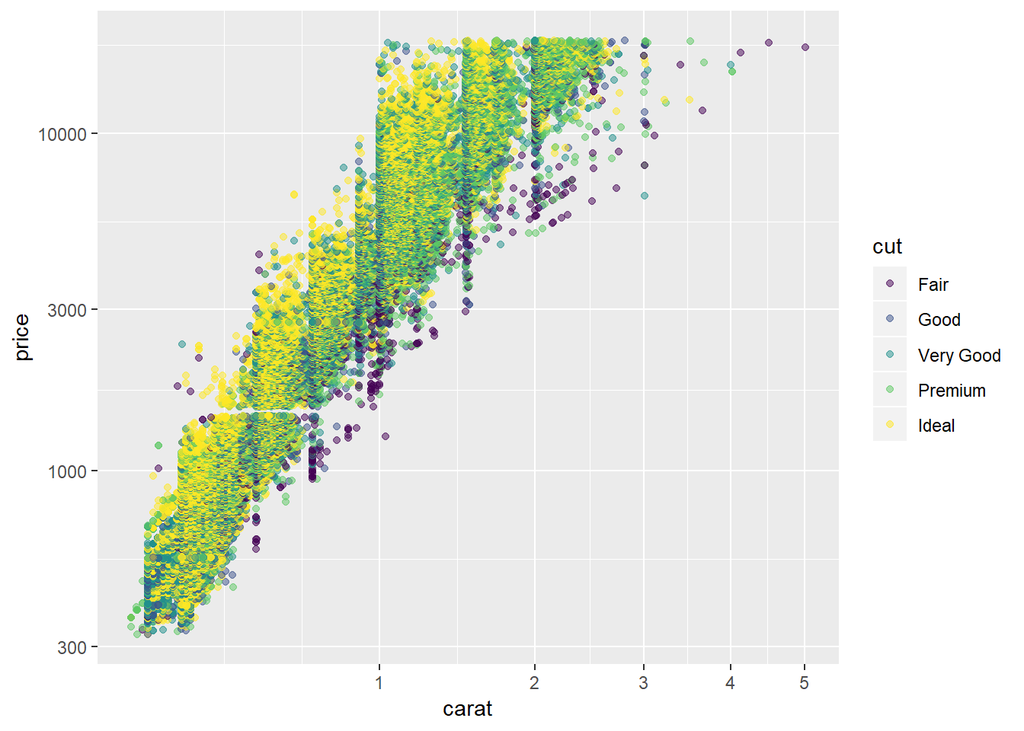

```r
ggplot(data = diamonds, aes(x = carat, y = price, color = cut))+
  geom_point(alpha = 1/2, position = position_jitter())+
  scale_x_continuous(trans = cuberoot_trans())+
  scale_y_continuous(trans = log10_trans())
```

**探索分析：** - 同一克拉下，价格没有出现明显的分离，切割质量对于价格影响不是很大

### 4.4 价格、克拉及纯净度三者的关系

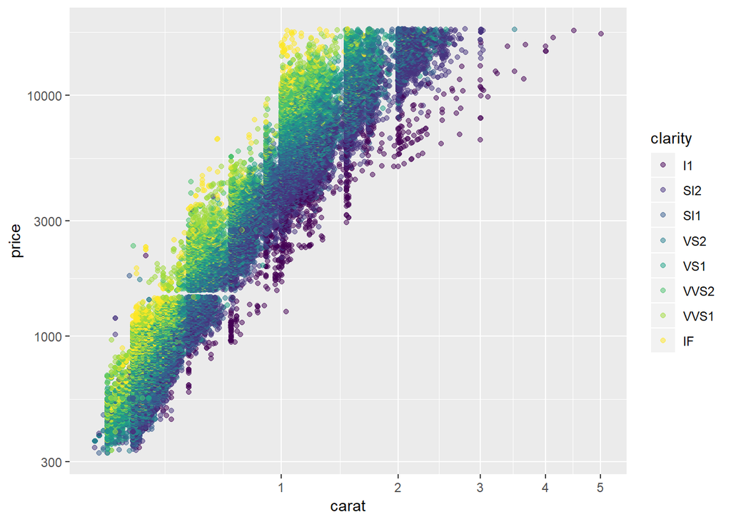

```r
ggplot(data = diamonds, aes(x = carat, y = price, color = clarity))+
  geom_point(alpha = 1/2, position = position_jitter())+
  scale_x_continuous(trans = cuberoot_trans())+
  scale_y_continuous(trans = log10_trans())
```

**探索分析**

- 可以发现纯净度出现了分离
- 同一克拉钻石，随着纯净度质量越高，价格就越高

### 4.5 价格、table及切割质量之间关系

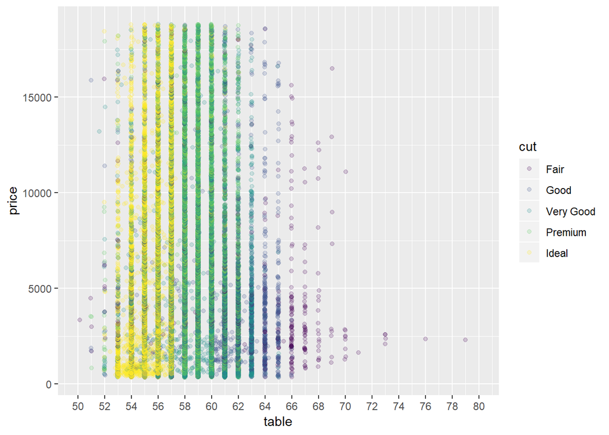

```r
ggplot(data = diamonds, aes(x = table, y = price, color = cut))+
  geom_point(alpha = 1/5, position = position_jitter())+
  scale_x_continuous(limits = c(50,80), breaks = seq(50,80,2))
```

**探索分析：**

- 可以发现不同切割质量的钻石的table范围不同,说明钻石切割质量和table参数有一定相关性
- 切割质量ideal的钻石范围为53-57，premium和very good的钻石的table范围为58-62，good和fair的钻石的table在63-68
- 钻石切割质量越好，table值会相比越小,

### 4.6 模拟预测价格的模型

```r
m1<- lm(formula = I(log(price))~I(carat^(1/3)),data = diamonds)
m2<- lm(formula = I(log(price))~I(carat^(1/3))+carat,data = diamonds)
m3<- lm(formula = I(log(price))~I(carat^(1/3))+carat+color,data = diamonds)
m4<- lm(formula = I(log(price))~I(carat^(1/3))+carat+color+cut,data = diamonds)
m5<- lm(formula = I(log(price))~I(carat^(1/3))+carat+color+cut+clarity,data = diamonds)

mtable(m1,m2,m3,m4,m5)
```

```
##
## Calls:
## m1: lm(formula = I(log(price)) ~ I(carat^(1/3)), data = diamonds)
## m2: lm(formula = I(log(price)) ~ I(carat^(1/3)) + carat, data = diamonds)
## m3: lm(formula = I(log(price)) ~ I(carat^(1/3)) + carat + color,
##     data = diamonds)
## m4: lm(formula = I(log(price)) ~ I(carat^(1/3)) + carat + color +
##     cut, data = diamonds)
## m5: lm(formula = I(log(price)) ~ I(carat^(1/3)) + carat + color +
##     cut + clarity, data = diamonds)
##
## ============================================================================================
##                        m1             m2             m3             m4            m5
## --------------------------------------------------------------------------------------------
##   (Intercept)          2.821***       1.039***       1.096***      0.932***       0.415***
##                       (0.006)        (0.019)        (0.017)       (0.017)        (0.010)
##   I(carat^(1/3))       5.558***       8.568***       8.303***      8.438***       9.144***
##                       (0.007)        (0.032)        (0.029)       (0.028)        (0.016)
##   carat                              -1.137***      -0.966***     -0.992***      -1.093***
##                                      (0.012)        (0.011)       (0.010)        (0.006)
##   color: .L                                         -0.373***     -0.373***      -0.441***
##                                                     (0.004)       (0.003)        (0.002)
##   color: .Q                                         -0.132***     -0.129***      -0.093***
##                                                     (0.003)       (0.003)        (0.002)
##   color: .C                                         -0.002         0.001         -0.013***
##                                                     (0.003)       (0.003)        (0.002)
##   color: ^4                                          0.029***      0.029***       0.012***
##                                                     (0.003)       (0.003)        (0.002)
##   color: ^5                                         -0.018***     -0.016***      -0.003*
##                                                     (0.003)       (0.003)        (0.001)
##   color: ^6                                         -0.027***     -0.023***       0.001
##                                                     (0.002)       (0.002)        (0.001)
##   cut: .L                                                          0.224***       0.120***
##                                                                   (0.004)        (0.002)
##   cut: .Q                                                         -0.062***      -0.031***
##                                                                   (0.003)        (0.002)
##   cut: .C                                                          0.052***       0.014***
##                                                                   (0.003)        (0.002)
##   cut: ^4                                                          0.018***      -0.002
##                                                                   (0.002)        (0.001)
```

[output cut: 11 more lines]

```
##                                                                                  (0.002)
##   clarity: ^7                                                                     0.032***
##                                                                                  (0.001)
## --------------------------------------------------------------------------------------------
##   R-squared            0.924          0.935          0.947         0.951          0.984
##   adj. R-squared       0.924          0.935          0.947         0.951          0.984
##   sigma                0.280          0.259          0.233         0.224          0.129
##   F               652012.063     387489.366     120932.024     87959.467     173791.084
##   p                    0.000          0.000          0.000         0.000          0.000
##   Log-likelihood   -7962.499      -3631.319       2002.977      4235.240      34091.272
##   Deviance          4242.831       3613.360       2932.128      2699.212        892.214
##   AIC              15930.999       7270.637      -3985.953     -8442.481     -68140.544
##   BIC              15957.685       7306.220      -3896.997     -8317.942     -67953.736
##   N                53940          53940          53940         53940          53940
## ============================================================================================
```

预测钻石价格：

carat为1.01，cut为Ideal，color为E，clarity为VS2的钻石的价格，置信区域为0.95：

```r
diamond1 <- data.frame(carat = 1.01, cut = "Ideal", color = "E", clarity = "VS2")

pred_price <- predict(m5, newdata = diamond1, interval = "prediction", level = 0.95)

exp(pred_price)
```

```
##       fit      lwr      upr
## 1 6231.52 4842.667 8018.689
```

95%置信水平上，预测的钻石价格的区间在4842.667-8018.689

**探索说明：**

- 从模型参数来看，该模型中变量可以解释98.4%的price变量
- 单用变量carat模拟模型，只能解释93.5%的price变量
- 钻石价格不仅仅只受模型中变量的影响，也会受其他未考虑因素的影响，比如通货膨胀、供需关系、以及购买时间等等因素，不能过分依赖模型

## 5.总结与反思

1. 此次探索分析我主要围绕钻石价格受哪些因素的影响展开，分别通过对单一变量分布，双变量以及多变量之间关系分析，来理解数据结构及数据之间的关系，最后根据建立的变量间关系，拟合了预测钻石价格的模型。
2. 介于对钻石行业及相关参数的理解不到位，不能很好的解释和深入分析一些情况，需要进一步对钻石的了解，来挖掘这些问题，如对比不同纯净度的价格中位数发现纯净度最高的钻石价格中位数最低，对比不同切割质量钻石的价格中位数时发现切割质量最高的价格中位数最低，以及同一克拉钻石，切割质量和价格关系没有明显趋势
3. 本次探索数据分析对我未来数据分析工作提供了一个思考框架：
- 了解数据源及数据结构和数据类型
- 单一变量分析及总结：探索单一变量理解各个变量的分布及情况，了解兴趣点
- 双变量分析及总结：根据目的，探索两个变量之间的关系
- 多变量分析及总结：基于前两个分析，深入分析变量间的关系，深刻理解数据
- 迭代探索分析过程
- 总结分析的结果，交流结果
- 总结与反省